# Pollution Analysis

```python
import numpy as np
import pandas as pd
import matplotlib.pyplot as plt
import seaborn as sns
```

```python
data1 = pd.read_csv('air_pollution.csv')
data1
```

|  | city | country | 2017 | 2018 | 2019 | 2020 | 2021 | 2022 | 2023 |
| --- | --- | --- | --- | --- | --- | --- | --- | --- | --- |
| 0 | Kabul | Afghanistan | 0 | 61.8 | 58.8 | 46.5 | 37.5 | 17.1 | 18.1 |
| 1 | Tirana | Albania | 0 | 0 | 0 | 16.0 | 12.5 | 14.5 | 14.4 |
| 2 | Algiers | Algeria | 0 | 0 | 21.2 | 20.2 | 20.0 | 17.8 | 17.4 |
| 3 | Ordino | Andorra | 0 | 0 | 0 | 7.4 | 7.3 | 5.4 | 5.3 |
| 4 | Luanda | Angola | 0 | 0 | 15.9 | 13.0 | 11.0 | 8.8 | 8.7 |
| ... | ... | ... | ... | ... | ... | ... | ... | ... | ... |
| 6980 | Thanh Pho Lang Son | Vietnam | 0 | 0 | 0 | 0 | 36.8 | 14.6 | 15.0 |
| 6981 | Thu Duc | Vietnam | 0 | 0 | 0 | 0 | 20.1 | 24.5 | 24.5 |
| 6982 | Tra Vinh | Vietnam | 0 | 0 | 0 | 0 | 6.2 | 5.5 | 5.5 |
| 6983 | Trang Bang | Vietnam | 0 | 0 | 0 | 0 | 0 | 12.9 | 12.4 |
| 6984 | Lusaka | Zambia | 0 | 0 | 0 | 0 | 24.6 | 24.6 | 24.4 |

6985 rows × 9 columns

```python
data1.head()
```

|  | city | country | 2017 | 2018 | 2019 | 2020 | 2021 | 2022 | 2023 |
| --- | --- | --- | --- | --- | --- | --- | --- | --- | --- |
| 0 | Kabul | Afghanistan | 0 | 61.8 | 58.8 | 46.5 | 37.5 | 17.1 | 18.1 |
| 1 | Tirana | Albania | 0 | 0 | 0 | 16.0 | 12.5 | 14.5 | 14.4 |
| 2 | Algiers | Algeria | 0 | 0 | 21.2 | 20.2 | 20.0 | 17.8 | 17.4 |
| 3 | Ordino | Andorra | 0 | 0 | 0 | 7.4 | 7.3 | 5.4 | 5.3 |
| 4 | Luanda | Angola | 0 | 0 | 15.9 | 13.0 | 11.0 | 8.8 | 8.7 |

```python
data1.describe()
```

|  | city | country | 2017 | 2018 | 2019 | 2020 | 2021 | 2022 | 2023 |
| --- | --- | --- | --- | --- | --- | --- | --- | --- | --- |
| count | 6985 | 6985 | 6985 | 6985 | 6985 | 6985 | 6985 | 6985 | 6985 |
| unique | 6852 | 133 | 504 | 497 | 548 | 534 | 616 | 666 | 649 |
| top | Hamilton | USA | 0 | 0 | 0 | 0 | 0 | 8.4 | 8.8 |
| freq | 6 | 2612 | 4852 | 4681 | 3337 | 3125 | 786 | 87 | 91 |

```python
data1.info()
```

```
<class 'pandas.core.frame.DataFrame'>
RangeIndex: 6985 entries, 0 to 6984
Data columns (total 9 columns):
 #   Column   Non-Null Count  Dtype
---  ------   --------------  -----
 0   city     6985 non-null   object
 1   country  6985 non-null   object
 2   2017     6985 non-null   object
 3   2018     6985 non-null   object
 4   2019     6985 non-null   object
 5   2020     6985 non-null   object
 6   2021     6985 non-null   object
 7   2022     6985 non-null   object
 8   2023     6985 non-null   object
dtypes: object(9)
memory usage: 491.3+ KB
```

data from 2017 to 2023 should be of type float

# DATA CLEANING

```python
temp = data1.iloc[:,2:]
index_prob = temp.loc[temp["2023"].apply(len)>9].index
temp = temp.replace('^([^.]*\.[^.]*)\..*', r'\1', regex=True)
```

```python
temp.loc[index_prob].astype(float)
```

|  | 2017 | 2018 | 2019 | 2020 | 2021 | 2022 | 2023 |
| --- | --- | --- | --- | --- | --- | --- | --- |
| 891 | 48.9 | 40.8 | 41.00 | 35.80 | 24.050 | 23.750 | 23.799 |
| 1103 | 41.8 | 38.0 | 35.75 | 30.55 | 27.450 | 26.099 | 26.099 |
| 2380 | 12.4 | 12.4 | 11.70 | 6.90 | 7.750 | 7.949 | 7.949 |
| 2563 | 11.6 | 11.1 | 10.90 | 10.40 | 9.033 | 9.333 | 9.299 |
| 2801 | 11.0 | 11.6 | 10.70 | 10.20 | 8.750 | 8.866 | 8.833 |
| ... | ... | ... | ... | ... | ... | ... | ... |
| 6182 | 0.0 | 0.0 | 0.00 | 0.00 | 10.000 | 71.000 | 71.000 |
| 6217 | 0.0 | 0.0 | 9.70 | 8.90 | 10.950 | 76.499 | 76.499 |
| 6542 | 9.1 | 8.3 | 7.90 | 8.30 | 4.949 | 8.649 | 8.649 |
| 6548 | 0.0 | 0.0 | 0.00 | 0.00 | 16.500 | 71.000 | 7.300 |
| 6587 | 0.0 | 0.0 | 0.00 | 0.00 | 9.900 | 8.325 | 8.325 |

64 rows × 7 columns

```python
year = list(temp.columns)
data1[year] = temp.astype(float)
data1.loc[index_prob].info()
```

```
<class 'pandas.core.frame.DataFrame'>
Int64Index: 64 entries, 891 to 6587
Data columns (total 9 columns):
 #   Column   Non-Null Count  Dtype
---  ------   --------------  -----
 0   city     64 non-null     object
 1   country  64 non-null     object
 2   2017     64 non-null     float64
 3   2018     64 non-null     float64
 4   2019     64 non-null     float64
 5   2020     64 non-null     float64
 6   2021     64 non-null     float64
 7   2022     64 non-null     float64
 8   2023     64 non-null     float64
dtypes: float64(7), object(2)
memory usage: 5.0+ KB
```

Here we can see that the type of data is in accordance with what we want. we check whether there are nulls

```python
print(data1.isnull().sum())
```

```
city       0
country    0
2017       0
2018       0
2019       0
2020       0
2021       0
2022       0
2023       0
dtype: int64
```

we did not find any null values in the data. this is good news. but we check how many zero values are in the data

```python
zero_value = (data1[year] == 0).sum()
zero_percentage = zero_value/ len(data1) * 100
zero_in_data = pd.DataFrame({
    "Count of zero": zero_value,
    "Percentage": zero_percentage
})
print("zero in data:")
print(zero_in_data)
```

```
zero in data:
      Count of zero  Percentage
2017           4852   69.463135
2018           4681   67.015032
2019           3337   47.773801
2020           3125   44.738726
2021            786   11.252684
2022              0    0.000000
2023              0    0.000000
```

we will eliminate data that contains zeros

```python
data1_cleaned = data1[~(data1.iloc[:, 6:] == 0).any(axis=1)]
data1[(data1.iloc[:, 6:] == 0).any(axis=1)]
print("percent of data obtained from original data")
print(f"{data1_cleaned.shape[0]/data1.shape[0] * 100}")
```

```
percent of data obtained from original data
88.74731567644953
```

```python
data1[(data1.iloc[:, 2:] == 0).any(axis=1)]
```

|  | city | country | 2017 | 2018 | 2019 | 2020 | 2021 | 2022 | 2023 |
| --- | --- | --- | --- | --- | --- | --- | --- | --- | --- |
| 0 | Kabul | Afghanistan | 0.0 | 61.8 | 58.8 | 46.5 | 37.5 | 17.1 | 18.1 |
| 1 | Tirana | Albania | 0.0 | 0.0 | 0.0 | 16.0 | 12.5 | 14.5 | 14.4 |
| 2 | Algiers | Algeria | 0.0 | 0.0 | 21.2 | 20.2 | 20.0 | 17.8 | 17.4 |
| 3 | Ordino | Andorra | 0.0 | 0.0 | 0.0 | 7.4 | 7.3 | 5.4 | 5.3 |
| 4 | Luanda | Angola | 0.0 | 0.0 | 15.9 | 13.0 | 11.0 | 8.8 | 8.7 |
| ... | ... | ... | ... | ... | ... | ... | ... | ... | ... |
| 6980 | Thanh Pho Lang Son | Vietnam | 0.0 | 0.0 | 0.0 | 0.0 | 36.8 | 14.6 | 15.0 |
| 6981 | Thu Duc | Vietnam | 0.0 | 0.0 | 0.0 | 0.0 | 20.1 | 24.5 | 24.5 |
| 6982 | Tra Vinh | Vietnam | 0.0 | 0.0 | 0.0 | 0.0 | 6.2 | 5.5 | 5.5 |
| 6983 | Trang Bang | Vietnam | 0.0 | 0.0 | 0.0 | 0.0 | 0.0 | 12.9 | 12.4 |
| 6984 | Lusaka | Zambia | 0.0 | 0.0 | 0.0 | 0.0 | 24.6 | 24.6 | 24.4 |

4961 rows × 9 columns

```python
data1_cleaned = data1_cleaned.drop(data1_cleaned.columns[2:6], axis=1)
data1_cleaned
```

|  | city | country | 2021 | 2022 | 2023 |
| --- | --- | --- | --- | --- | --- |
| 0 | Kabul | Afghanistan | 37.5 | 17.1 | 18.1 |
| 1 | Tirana | Albania | 12.5 | 14.5 | 14.4 |
| 2 | Algiers | Algeria | 20.0 | 17.8 | 17.4 |
| 3 | Ordino | Andorra | 7.3 | 5.4 | 5.3 |
| 4 | Luanda | Angola | 11.0 | 8.8 | 8.7 |
| ... | ... | ... | ... | ... | ... |
| 6979 | Thanh Pho Ha Long | Vietnam | 10.7 | 9.0 | 8.9 |
| 6980 | Thanh Pho Lang Son | Vietnam | 36.8 | 14.6 | 15.0 |
| 6981 | Thu Duc | Vietnam | 20.1 | 24.5 | 24.5 |
| 6982 | Tra Vinh | Vietnam | 6.2 | 5.5 | 5.5 |
| 6984 | Lusaka | Zambia | 24.6 | 24.6 | 24.4 |

6199 rows × 5 columns

```python
data1_cleaned.describe()
```

|  | 2021 | 2022 | 2023 |
| --- | --- | --- | --- |
| count | 6199.000000 | 6199.000000 | 6199.000000 |
| mean | 14.121739 | 12.848708 | 12.831575 |
| std | 11.233194 | 10.967151 | 10.998632 |
| min | 1.500000 | 0.500000 | 0.600000 |
| 25% | 8.000000 | 7.100000 | 7.000000 |
| 50% | 10.500000 | 9.300000 | 9.300000 |
| 75% | 16.000000 | 14.100000 | 14.000000 |
| max | 175.900000 | 97.400000 | 97.400000 |

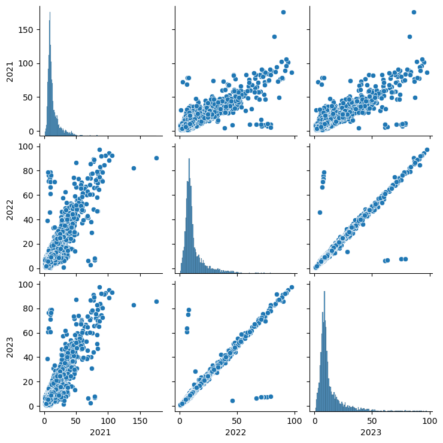

```python
sns.pairplot(data1_cleaned.iloc[:, 1:])
plt.show()
```

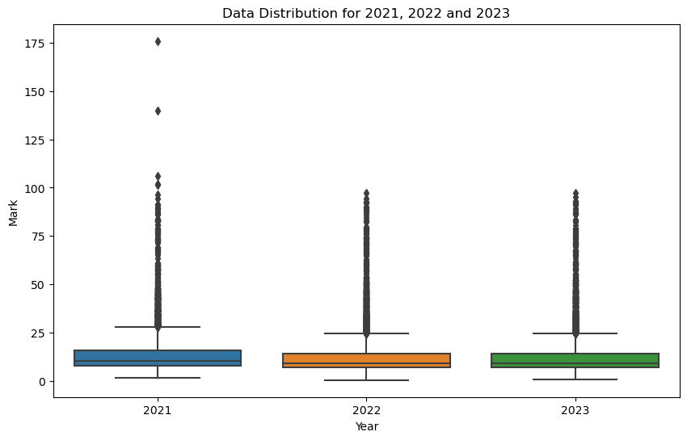

```python
plt.figure(figsize=(10, 6))
sns.boxplot(data=data1_cleaned.iloc[:, 1:])
plt.xlabel('Year')
plt.ylabel('Mark')
plt.title('Data Distribution for 2021, 2022 and 2023')
plt.show()
```

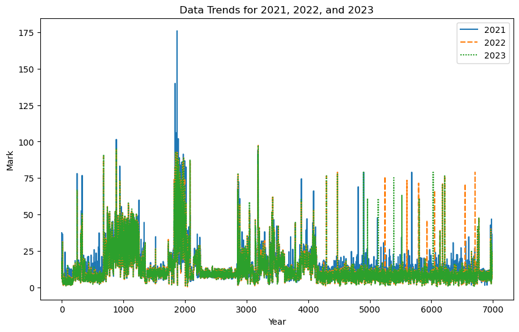

```python
plt.figure(figsize=(10, 6))
sns.lineplot(data=data1_cleaned.iloc[:, 1:])
plt.xlabel('Year')
plt.ylabel('Mark')
plt.title('Data Trends for 2021, 2022, and 2023')
plt.show()
```

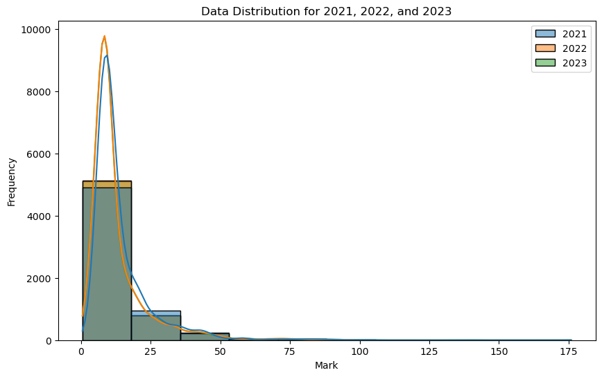

```python
plt.figure(figsize=(10, 6))
sns.histplot(data=data1_cleaned.iloc[:, 1:], bins=10, kde=True)
plt.xlabel('Mark')
plt.ylabel('Frequency')
plt.title('Data Distribution for 2021, 2022, and 2023')
plt.show()
```

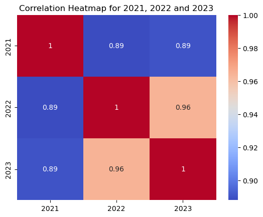

```python
sns.heatmap(data1_cleaned.iloc[:, 2:].corr(), annot=True, cmap='coolwarm')
plt.title('Correlation Heatmap for 2021, 2022 and 2023')
plt.show()
```

```python
data1_cleaned["diff_21_22"] = data1_cleaned['2022'] - data1_cleaned['2021']
data1_cleaned["diff_22_23"] = data1_cleaned['2023'] - data1_cleaned['2022']

data1_cleaned[(data1_cleaned['diff_21_22']>20) | (data1_cleaned['diff_22_23']>20)]
```

|  | city | country | 2021 | 2022 | 2023 | diff_21_22 | diff_22_23 |
| --- | --- | --- | --- | --- | --- | --- | --- |
| 1870 | Dadri | India | 46.800 | 69.300 | 71.500 | 22.500 | 2.200 |
| 1890 | Gaya | India | 46.600 | 74.300 | 73.600 | 27.700 | -0.700 |
| 2083 | Baghdad | Iraq | 49.700 | 86.700 | 87.300 | 37.000 | 0.600 |
| 2890 | Kuwait City | Kuwait | 29.700 | 57.500 | 57.300 | 27.800 | -0.200 |
| 3425 | Dhahran | Saudi Arabia | 33.000 | 62.800 | 61.700 | 29.800 | -1.100 |
| 4298 | Bellevue | USA | 6.950 | 76.499 | 76.499 | 69.549 | 0.000 |
| 4476 | Canton | USA | 9.400 | 78.999 | 77.749 | 69.599 | -1.250 |
| 4900 | Fayetteville | USA | 9.333 | 7.866 | 78.999 | -1.467 | 71.133 |
| 4964 | Frisco | USA | 9.850 | 6.250 | 61.000 | -3.600 | 54.750 |
| 5137 | Henderson | USA | 5.700 | 6.200 | 61.000 | 0.500 | 54.800 |
| 5247 | Jackson | USA | 10.650 | 76.000 | 7.625 | 65.350 | -68.375 |
| 5391 | Lancaster | USA | 10.000 | 7.560 | 75.200 | -2.440 | 67.640 |
| 5522 | Manchester | USA | 6.500 | 6.450 | 63.500 | -0.050 | 57.050 |
| 5604 | Miami | USA | 8.700 | 73.500 | 7.400 | 64.800 | -66.100 |
| 5794 | Oak Harbor | USA | 7.350 | 71.499 | 7.200 | 64.149 | -64.299 |
| 5802 | Oakley | USA | 9.850 | 61.000 | 61.000 | 51.150 | 0.000 |
| 5929 | Piedmont | USA | 8.500 | 46.000 | 4.650 | 37.500 | -41.350 |
| 6030 | Quincy | USA | 11.333 | 7.900 | 78.999 | -3.433 | 71.099 |
| 6053 | Redlands | USA | 10.200 | 66.499 | 6.600 | 56.299 | -59.899 |
| 6141 | Saint George | USA | 4.900 | 39.000 | 38.499 | 34.100 | -0.501 |
| 6182 | San Marcos | USA | 10.000 | 71.000 | 71.000 | 61.000 | 0.000 |
| 6217 | Savage | USA | 10.950 | 76.499 | 76.499 | 65.549 | 0.000 |
| 6548 | Victor | USA | 16.500 | 71.000 | 7.300 | 54.500 | -63.700 |
| 6710 | Woodbine | USA | 5.600 | 78.999 | 7.900 | 73.399 | -71.099 |

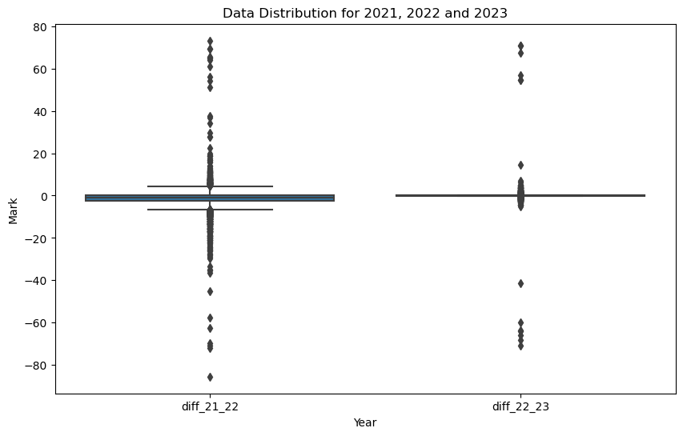

```python
plt.figure(figsize=(10, 6))
sns.boxplot(data=data1_cleaned.iloc[:, -2:])
plt.xlabel('Year')
plt.ylabel('Mark')
plt.title('Data Distribution for 2021, 2022 and 2023')
plt.show()
```

```python
data1_cleaned[(data1_cleaned['diff_21_22']>40) | (data1_cleaned['diff_22_23']>40)]
```

|  | city | country | 2021 | 2022 | 2023 | diff_21_22 | diff_22_23 |
| --- | --- | --- | --- | --- | --- | --- | --- |
| 4298 | Bellevue | USA | 6.950 | 76.499 | 76.499 | 69.549 | 0.000 |
| 4476 | Canton | USA | 9.400 | 78.999 | 77.749 | 69.599 | -1.250 |
| 4900 | Fayetteville | USA | 9.333 | 7.866 | 78.999 | -1.467 | 71.133 |
| 4964 | Frisco | USA | 9.850 | 6.250 | 61.000 | -3.600 | 54.750 |
| 5137 | Henderson | USA | 5.700 | 6.200 | 61.000 | 0.500 | 54.800 |
| 5247 | Jackson | USA | 10.650 | 76.000 | 7.625 | 65.350 | -68.375 |
| 5391 | Lancaster | USA | 10.000 | 7.560 | 75.200 | -2.440 | 67.640 |
| 5522 | Manchester | USA | 6.500 | 6.450 | 63.500 | -0.050 | 57.050 |
| 5604 | Miami | USA | 8.700 | 73.500 | 7.400 | 64.800 | -66.100 |
| 5794 | Oak Harbor | USA | 7.350 | 71.499 | 7.200 | 64.149 | -64.299 |
| 5802 | Oakley | USA | 9.850 | 61.000 | 61.000 | 51.150 | 0.000 |
| 6030 | Quincy | USA | 11.333 | 7.900 | 78.999 | -3.433 | 71.099 |
| 6053 | Redlands | USA | 10.200 | 66.499 | 6.600 | 56.299 | -59.899 |
| 6182 | San Marcos | USA | 10.000 | 71.000 | 71.000 | 61.000 | 0.000 |
| 6217 | Savage | USA | 10.950 | 76.499 | 76.499 | 65.549 | 0.000 |
| 6548 | Victor | USA | 16.500 | 71.000 | 7.300 | 54.500 | -63.700 |
| 6710 | Woodbine | USA | 5.600 | 78.999 | 7.900 | 73.399 | -71.099 |

```python
for i, row in data1_cleaned.iterrows():
    if (abs(row["diff_21_22"]) > 40) and (abs(row["diff_22_23"]) > 40):
        data1_cleaned.at[i, '2022'] = row['2022'] / 10 if row["diff_21_22"] > 0 else row['2022'] * 10
    elif (abs(row["diff_21_22"]) > 40) and (abs(row["diff_22_23"]) < 40):
        data1_cleaned.at[i, '2021'] = row['2021'] * 10 if row["diff_21_22"] > 0 else row['2021'] / 10
    elif (abs(row["diff_21_22"]) < 40) and (abs(row["diff_22_23"]) > 40):
        data1_cleaned.at[i, '2023'] = row['2023'] / 10 if row['diff_22_23'] > 0 else row['2023'] * 10
    else:
        data1_cleaned.at[i, '2023'] = row["2023"]
        data1_cleaned.at[i, '2022'] = row["2022"]
        data1_cleaned.at[i, '2021'] = row["2021"]
```

```python
# data1_cleaned = data1_cleaned.drop(columns = ["diff_21_22", "diff_22_23"])
data1_cleaned[(data1_cleaned['diff_21_22']>40) | (data1_cleaned['diff_22_23']>40)]
```

|  | city | country | 2021 | 2022 | 2023 | diff_21_22 | diff_22_23 |
| --- | --- | --- | --- | --- | --- | --- | --- |
| 4298 | Bellevue | USA | 69.500 | 76.4990 | 76.4990 | 69.549 | 0.000 |
| 4476 | Canton | USA | 94.000 | 78.9990 | 77.7490 | 69.599 | -1.250 |
| 4900 | Fayetteville | USA | 9.333 | 7.8660 | 7.8999 | -1.467 | 71.133 |
| 4964 | Frisco | USA | 9.850 | 6.2500 | 6.1000 | -3.600 | 54.750 |
| 5137 | Henderson | USA | 5.700 | 6.2000 | 6.1000 | 0.500 | 54.800 |
| 5247 | Jackson | USA | 10.650 | 7.6000 | 7.6250 | 65.350 | -68.375 |
| 5391 | Lancaster | USA | 10.000 | 7.5600 | 7.5200 | -2.440 | 67.640 |
| 5522 | Manchester | USA | 6.500 | 6.4500 | 6.3500 | -0.050 | 57.050 |
| 5604 | Miami | USA | 8.700 | 7.3500 | 7.4000 | 64.800 | -66.100 |
| 5794 | Oak Harbor | USA | 7.350 | 7.1499 | 7.2000 | 64.149 | -64.299 |
| 5802 | Oakley | USA | 98.500 | 61.0000 | 61.0000 | 51.150 | 0.000 |
| 6030 | Quincy | USA | 11.333 | 7.9000 | 7.8999 | -3.433 | 71.099 |
| 6053 | Redlands | USA | 10.200 | 6.6499 | 6.6000 | 56.299 | -59.899 |
| 6182 | San Marcos | USA | 100.000 | 71.0000 | 71.0000 | 61.000 | 0.000 |
| 6217 | Savage | USA | 109.500 | 76.4990 | 76.4990 | 65.549 | 0.000 |
| 6548 | Victor | USA | 16.500 | 7.1000 | 7.3000 | 54.500 | -63.700 |
| 6710 | Woodbine | USA | 5.600 | 7.8999 | 7.9000 | 73.399 | -71.099 |

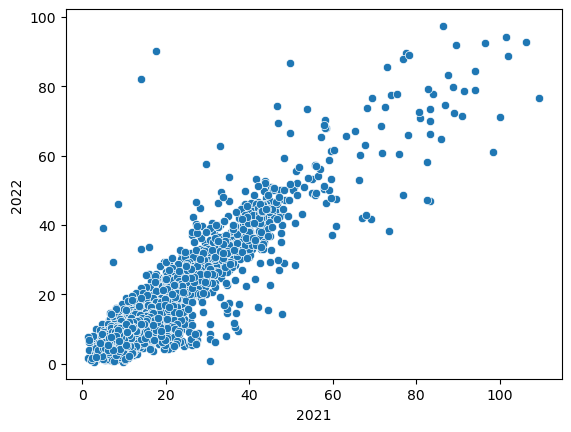

```python
sns.scatterplot(data = data1_cleaned, x='2021', y='2022')
```

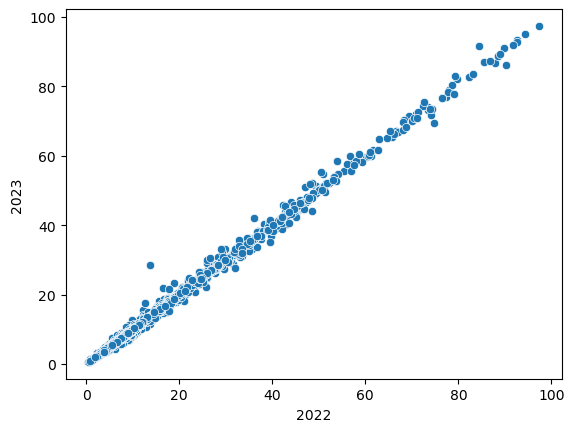

```python
sns.scatterplot(data = data1_cleaned, x='2022', y='2023')
```

```python
data1_cleaned = data1_cleaned.drop(columns = ["diff_21_22","diff_22_23"])
data1_cleaned['diff_21_22'] = data1_cleaned['2022'] - data1_cleaned['2021']
data1_cleaned['diff_22_23'] = data1_cleaned['2023'] - data1_cleaned['2022']
```

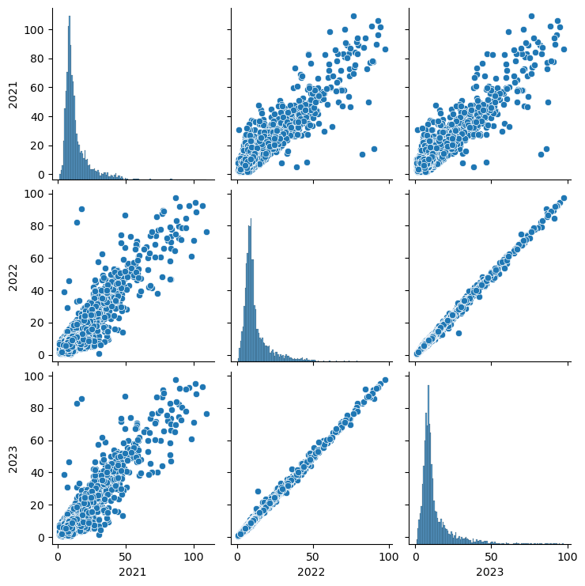

```python
sns.pairplot(data1_cleaned.iloc[:, 1:-2])
plt.show()
```

```
No artists with labels found to put in legend.  Note that artists whose label start with an underscore are ignored when legend() is called with no argument.
```

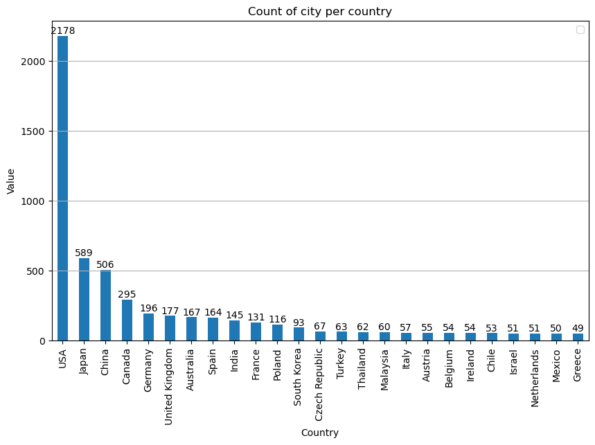

```python
grouped_count = data1_cleaned.groupby('country').size()
n = 25
ax = grouped_count.nlargest(n).plot(kind='bar', figsize=(10, 6))
for i, value in enumerate(grouped_count.nlargest(n)):
    ax.annotate(str(value), xy=(i, value), ha='center', va='bottom')
plt.title('Count of city per country')
plt.xlabel('Country')
plt.ylabel('Value')
plt.grid(axis='y')
plt.legend(loc='upper right')
plt.show()
```

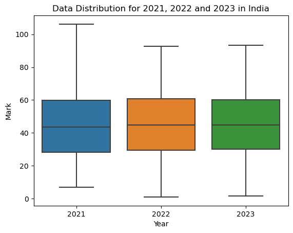

```python
India_AQI = data1_cleaned[data1_cleaned['country'].isin(['India'])].sort_values(by = '2023', ascending = True)
sns.boxplot(data=India_AQI.iloc[:, :-2])
plt.xlabel('Year')
plt.ylabel('Mark')
plt.title('Data Distribution for 2021, 2022 and 2023 in India')
plt.show()
```

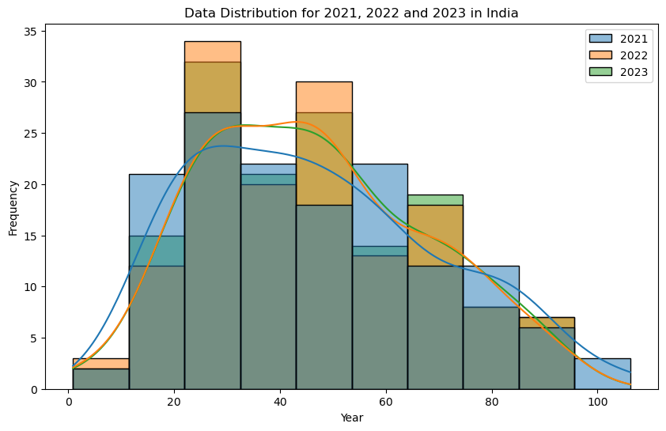

```python
plt.figure(figsize=(10, 6))
sns.histplot(data=India_AQI.iloc[:, :-2], bins=10, kde=True)
plt.xlabel('Year')
plt.ylabel('Frequency')
plt.title('Data Distribution for 2021, 2022 and 2023 in India')
plt.show()
```